# from_text_to_measurement

```r
rm(list = ls())

library(dictvectoR)
library(dplyr)
library(fastrtext)
library(magrittr)
library(quanteda)
library(ggplot2)
```

## Introduction

This vignette guides you through the workflow described in Thiele (2022) in applying the ‘Distributed Dictionary Representation’ (DDR) Method (Garten et al., 2018) and introduces most functions of the dictvectoR package.

The DDR method provides a continuous measurement of a concept in a dataset of documents. This measurement is obtained by calculating an average word vector representation of a concept dictionary, and representations of each document, and calculating the cosine similarity between those two vectors. For a detailed description, see Garten et al. (2018) and Thiele (2022).

## Overview

The workflow described here starts from scratch, using only textual data as input, guides through steps for finding inductively a list of keywords, and demonstrates the evaluation and application.

It requires a population dataset containing textual data and a hand-coded sample drawn from this dataset, annotated for the presence of a theoretical concept. We use the built-in dataset `tw_data` as population data and `tw_annot` as annotated sample.

The vignette follows these steps:

1. Pre-process data
2. Train fastText model
3. Finding keywords
4. Add multi-words
5. Get F1 scores
6. Drop similar terms
7. Narrowing down by hand
8. Get combinations of terms.
9. Evaluate performance of combinations.
10. Apply best performing dictionary.
11. Face validity.

## Pre-process data

First we load and pre-process the built in textual data.

`clean_text` cleans the text and is tailored to German-speaking texts on social media. If you are using text in other languages, you may want to adapt this helper-function to your own needs.

`prepare_train_data` prepares textual data for training a fastText model. It tokenizes longer documents into sentences, shuffles them, and calls `clean_text` with fixed settings.

We first prepare a `texts` character vector for training the fastText model, and clean the text in `tw_data` and `tw_annot` for our later analyses.

```r
# Prepare text data
texts <- prepare_train_data(tw_data, text_field = "full_text", seed = 42)

# Clean text in tw_data
tw_data %<>% clean_text(remove_stopwords = T,
                        text_field = "full_text")

# Clean text in tw_annot
tw_annot %<>% clean_text(remove_stopwords = T,
                         text_field = "full_text")
```

## Train fastText model

Now, we train our own fastText model using `fastrtext::build_vectors`.

A customized word vector model has the advantage that it maps the words and contexts that actually appear in the studied material. This is important here, as we will use the vocabulary of the model as starting point for our conceptual dictionary.

The downside of training your own model is that it is expensive regarding memory and computation. I used a machine with a CPU @ 1.80GHz processor with 8 cores and 16 GB RAM. If you run into memory limitations, consider decreasing `dim`, the number of dimensions. Decreasing the number of `epochs` will speed up the learing process, and decreasing the `bucket` size will reduce the size of the resulting model. For details, see Bojanowski et al. (2017). To obtain a model with better quality, you also should consider increasing the size of textual data used for training. The example here is limited by the size of data that can be feasibly shipped in a R-package.

Alternatively, you may consider using a pre-trained model from [here](https://github.com/facebookresearch/fastText/blob/master/docs/crawl-vectors.md).

The code below creates a local folder `ft_model` in your user home directory, and saves the model as two files: `ft_model.bin` and `ft_model.vec`.

(Note: The code below only runs if the model file does not exists. The training algorithm does not create perfectly identical word vector models, which can cause problems when re-running the vignette.)

```r
# Create local folder and set name for model
dir.create("~/ft_model", showWarnings = FALSE)
model_file <- path.expand("~/ft_model/ft_model")

# Train a fasttext model using the twitter data (if model does not yet exist)

if (!file.exists(paste0(model_file, ".bin"))) {

  fastrtext::build_vectors(texts, model_file, modeltype = c("skipgram"),
                              dim = 150, epoch = 10, bucket = 1e+6,  lr = 0.05,
                              lrUpdateRate = 100, maxn = 7,  minn = 4, minCount = 3,
                              t = 1e-04, thread = 8, ws= 6)
  }
```

Let’s load the model and use a nearest-neighbor query to check if it works properly. ‘Spahn’ is the name of the former German minister of health:

```r
# Load model:
model_path <- path.expand("~/ft_model/ft_model.bin")
model <- fastrtext::load_model(paste0(model_path))

# Nearest-neigbor query:
fastrtext::get_nn(model, "spahn", k=8)
```

```
#>          spahns            jens   spahnversagen spahnruecktritt   maskenskandal
#>       0.9211217       0.7881474       0.7751120       0.7349917       0.7158434
#>    maskenaffäre      skandalöse   ffpzweimasken
#>       0.6748365       0.6505284       0.6460720
```

## Finding keywords

Next, we want to use the fastText model and the manually annotated dataset to find a short dictionary for populist communication.

First, we split the annotated data into a train and a test sample, using `caret::createDataPartition`.

```r
# set seed
set.seed(42)

# get index for splitting
train_id <- caret::createDataPartition(tw_annot$pop,
                                times = 1,
                                p = .7,
                                list = F)
# split annotated data
df_train <- tw_annot %>% slice(train_id)
df_test <- tw_annot %>% slice(-train_id)
```

As starting point for our dictionary, we use the vocabulary from the fastText model. We add the ID from the vocabulary and use `clean_text` to remove stopwords, and drop words of less than 3 characters from this list:

```r
# # Get vocabulary
vocab_df <- fastrtext::get_dictionary(model) %>% data.frame(words = .)

# Get vocabulary ID
vocab_df$word_id <- fastrtext::get_word_ids(model, vocab_df$words)

# remove stopwords
vocab_df <- clean_text(vocab_df,
                       text_field = "words",
                       remove_stopwords = T) %>%
            filter(n_words == 1,
                   n_chars > 2)
```

Next, we want to narrow down that list. We identify words that are similar to the hand-coded corpus of populist Tweets but dissimilar to non-populist Tweets in `df_train` using `find_distinctive`.

`find_distinctive` computes an average representation of that subset of the annotated corpus in which populism was coded as present, as well as a representation of the negative counterpart, i.e. of the non-populist corpus. It then computes the cosine similarities of each word in a dataframe to these two corpora, and calculates the difference between these two similarity scores. This provides us with a quick and computationally inexpensive shortcut to find keywords that capture a specific concept, but nothing else.

```r
# Get distinctive word scores
vocab_df <- find_distinctive(df_train,
                             concept_field = "pop",
                             text_field = "text",
                             word_df = vocab_df,
                             word_field = "words",
                             model = model)

vocab_df %<>% mutate(pop_distinctiveXpossim = pop_distinctive*pop_possim) %>%
              filter_ntile("pop_distinctiveXpossim", .75)
```

However, this method of narrowing down a list of keywords is a bit crude and not very informative for assessing how well a single word would perform when used in the DDR method.

Hence, we want to get the actual F1 scores for each single word, when used as a one-word-dicitonary in the DDR method. Note that the DDR method returns the cosine similarity as a continuous measure, theoretically ranging from -1 to +1, while our manually annotated dataset was coded in a binary fashion (populist or non-populist).

To solve this problem, the continuous measure is used as a independent variable in a logistic regression, predicting the manual binary coding. To obtain Recall, Precision and F1 scores, `dictvectoR` compares the binary predictions resulting from this regression with the manual coding. This is not a direct gold standard test but circumvents the problem of producing reliable granular codes manually (Grimmer & Stewart, 2013, p. 275).

Recall is an evaluation metric that indicates how well the automated measure captures all true positives, precision is indicates how well it captures only true positives, and F1 is a harmonic mean of both (Chinchor 1992).

`get_many_F1s` is a function that efficiently returns F1 scores for a list of words or dictionaries, when used in as dictionary in the DDR method.

```r
vocab_df$popF1 <- get_many_F1s(vocab_df$words,
                              model = model,
                              df = df_train,
                              reference = "pop")
```

We’re only interested in the best-performing quartile, which we extract using the helper-function `filter_ntile`:

```r
top <- vocab_df %>%
            filter_ntile("popF1", .75) %>%
            filter(popF1 > 0)
```

## Add multi-words

Some concepts are expressed rather in multi-word expressions than by single words. In our case, we suspect that people-centrism, one core dimension of populism, may involve such multiword expressions, for example by constructing an in-group with references to some ‘we’, e.g., ‘we taxpayers’, ‘our land’ etc.

To find common multiword expressions, we use the population data (that is 75 percent of it to speed up the process a bit), and tokenize it using `quanteda::tokens`.

```r
tw_data %<>% filter(n_words >= 2)

# Use 75% sample
set.seed(42)
tw_split <- tw_data %>% slice_sample(prop = .75)

# tokenize
toks <- quanteda::tokens(tw_split$text)
```

`add_multiwords` adds multiword expressions for a dataframe of single words and counts the occurences. Here we only look for multiwords in a 2-word-window (`level = 1`), which can be increased to a 3-words window (`level = 2`). This process might take two or three minutes.

```r
top <- add_multiwords(top,
                      tokens = toks,
                      min_hits = 1,
                      word_field = "words",
                      levels = 1)
```

```
#> [1] "Finding multi-word expressions in window = 1..."
#> [1] "Adding missing count of original words:"
#> [1] "Counting word occurrences..."
```

We want to narrow down this list again, filtering terms that occur only once. And we add a unique word_id by `add_word_id`.

```r
top %<>% filter(hits > 1)
top %<>% add_word_id()
```

## Get F1 scores

Now, we also want to know the F1 scores for the new multiword terms, hence we just run `get_many_F1s` again.

```r
top$popF1 <- get_many_F1s(top$words,
                          model = model,
                          df = df_train,
                          reference = "pop")
```

## Drop similar terms

The resulting list of words is quite long and includes a lot of redundancy. Note that unlike in traditional dictionary approaches, the DDR method performs better if the input dictionary is very short and clear-cut. While redundancy is not a problem for traditional dictionaries, it may distort the performance of the dictionary in DDR (Garten et al., 2018).

`remove_similar_words` helps us to detect similar terms - by computing the pairwise cosine similarity between all words representations in a datafram. It can use two score as input to decide which words to drop: Here we use the F1 score calculated before `popF1`, and the number of occurences (`compare_hits = T`). We set the function to compare only terms that reach a smiliarity of 60% (`min_simil = .6`). `win_threshold` defines the share of all comparisons that a term must win in order to remain in the dataframe.

Additionally, we drop terms that originate from the uni-word `afd`, the German populist party, since we want our populism measure to be rather non-partisan:

```r
## narrow down
top_subs <- top %>% remove_similar_words(model,
                                        compare_by = "popF1",
                                        compare_hits = T,
                                        min_simil = .6,
                                        win_threshold = .65) %>%
                    filter(!from == "afd")
```

## Narrowing down by hand

Let’s have a look at all terms found so far. (We won’t print all 400 or so terms here but only the top 50)

```r
top_subs %>% arrange(desc(popF1)) %>% pull(words) %>% head(50)
```

```
#>  [1] "panzer"                      "wahn"
#>  [3] "verrechnet"                  "deutschen steuerzahler"
#>  [5] "wand"                        "irrweg"
#>  [7] "rücken wand"                 "verrückt"
#>  [9] "skandalösen"                 "teures"
#> [11] "deutschen mittelstand"       "daimler vw"
#> [13] "mdb nimmt"                   "igmetall"
#> [15] "gaga"                        "teure"
#> [17] "skandalöse"                  "gender gaga"
#> [19] "steuergeldverschwendung"     "skandalös"
#> [21] "maskenskandal"               "irrsinnige"
#> [23] "betreibt"                    "rechnet"
#> [25] "vernichten"                  "vernichtet"
#> [27] "autofahrer"                  "existenzen vernichtet"
#> [29] "deutschland groko"           "knickt"
#> [31] "lobbyregister"               "vdk"
#> [33] "dax"                         "fachkräfte"
#> [35] "spahn warnt"                 "abgasnorm"
#> [37] "kette"                       "deckmantel"
#> [39] "deckt"                       "diesel fahrverbote"
#> [41] "kurzstreckenflüge verbieten" "steuerzahler"
#> [43] "mdb groko"                   "mittels"
#> [45] "autofahren"                  "schamlos"
#> [47] "unternimmt"                  "staatshaushalt"
#> [49] "einwanderungsministerium"    "linie rechnen"
```

This list of keywors is still quite long. It includes many terms that seem theoretically plausible, but also many words that obviously are either too specific, or seem out of place.

Since the next steps involve combinatorics for finding a good combination of keywords, we want to narrow down the list of words as drastically as possible.

For theoretical reasons, we decided to group the found words in three categories that reflect different aspects of populist communication: Terms that reflect ‘elites’, terms that reflect ‘the people’, and words that relate those two groups.

From the 400 or so terms, we hand-picked five distinctive terms for each of these categories. This mode of selection is theory-driven and different from the inductive logic used so far. You may want to opt for different modes of selection, depending on your task and the quality of inductively generated keywords. Here are the words picked for further processing:

```r
elites <- c(
"altparteien",
"lobbyisten",
"merkel co",
"plänen bundesregierung",
"zwangsgebühr"
)

people <- c(
"arbeitnehmern",
"existenzen",
"deutschen",
"deutschen mittelstand",
"deutschen steuerzahler"
)

relation <- c(
"entlarven",
"schamlos",
"verrückt",
"wahn",
"steuergeldverschwendung"
)
```

We use this hand-picked list of words to create a shortlist and add a variable that indicates the category:

```r
top_elites <- top_subs %>% filter(words %in% elites) %>% mutate(cat = "elites")
top_people <- top_subs %>% filter(words %in% people) %>% mutate(cat = "people")
top_relation <- top_subs %>% filter(words %in% relation) %>% mutate(cat = "relation")

shortlist <- bind_rows(top_elites, top_people, top_relation)
shortlist$cat %<>% factor()
shortlist$cat %>% summary()
```

```
#>   elites   people relation
#>        5        5        5
```

## Get combinations

We now use this shortlist to get all possible combinations of various length per category, and all possible combinations of these combinations.

`get_combis` helps us finding these combinations, and provides a useful random sampling mechanism that limits the number of returned combinations: Setting a `limit`, limits the number of combinations of a given length returned per dimension.

For example, consider that you have a shortlist of words with 2 categories A and B, with 10 words per category, and want find combinations of words that include at least 3 words per category (`min_per_dim = 3`) and maximum 10 words overall (`max_overall = 10`), i.e. max. 5 words per dimension.

Then you would have 120 possible combinations of length 3 for both category A and B:

```r
A <- c(1:10)
B <- c(11:20)

choose(10, 3)
```

```
#> [1] 120
```

However, you also get 210 possible combinations of length 4, and 252 combinations of length 5 per category:

```r
choose(10, 4)
```

```
#> [1] 210
```

```r
choose(10, 5)
```

```
#> [1] 252
```

If you want to get all possible combinations of these combinations, the number increases really quickly, as we can see below. The first two lines return all possible cominations for A and B of varying length between 3 and 5. `expand_grid` returns the combinations of combinations:

```r
A_c <- do.call("c", lapply(3:5, function(i) combn(A, i, FUN = list)))
B_c <- do.call("c", lapply(3:5, function(i) combn(B, i, FUN = list)))
expand.grid(A_c, B_c)  %>% nrow()
```

```
#> [1] 338724
```

Setting the `limit` to, let’s say 30, in `get_combis` radomly draws only 30 possible combinations of one length per category.

In our case, this limit is not really necessary, as we only have 5 words per category and want lengths between 3 and 4. The maximum number of combinations per length & category is 10:

```r
max(
  choose(5, 3),
  choose(5, 4)
)
```

```
#> [1] 10
```

Although unnecessary in our case, we specify a `limit` (that won’t drop any combinations) - just for demonstration. Setting `seed` makes your results reproducible, the default is `1`. `get_cobmis` returns a data.frame that includes a column where you’re settings are stored, in case you want to come back and draw a different round of combinations.

So, let’s get all combinations for our list of words:

```r
combis_rd <- get_combis(shortlist,
                        dims = "cat",
                        min_per_dim = 3,
                        max_overall = 12,
                        limit = 10,
                        seed = 42)
```

## Evaluate combinations

Now we want to get Recall, Precision, and F1 scores for all of the 3,375 combinations. `get_many_RPFs` is made for this task:

```r
combis_df <- get_many_RPFs(keyword_df = combis_rd,
                             keyword_field = "combs_split",
                             model = model,
                             text_df = df_train,
                             reference = "pop",
                             text_field = "text")
```

Now, let’s pick the best performing short dictionary:

```r
# Pick dictionary that maximizes F1:
dict  <- combis_df %>%
          filter(F1 == max(F1)) %>%
          pull(combs_split) %>%
          unlist()

# Let's see:
dict
```

```
#>  [1] "altparteien"             "arbeitnehmern"
#>  [3] "deutschen"               "deutschen steuerzahler"
#>  [5] "entlarven"               "merkel co"
#>  [7] "plänen bundesregierung"  "steuergeldverschwendung"
#>  [9] "verrückt"                "wahn"
```

These 10 words cover various aspects of populist communication and are highly context-specific. However, this is not the place to dive into theoretical discussions.

Let’s check the performance of the dictionary instead. On the training sample, this dictionary reaches an F1 of .56, which is not great, but OK.

```r
combis_df$F1 %>% max()
```

```
#> [1] 0.5568627
```

Let’s check the F1 score when applied on the test sample:

```r
# Performance for test_df
get_F1(df_test, dict, model, 'pop')
```

```
#> [1] 0.5544554
```

The short dictionary reaches a F1 of .55 in the test sample, which is almost par with the result for the train data. Drawing on this evaluation, we have some reason to assume that we avoided overfitting the dictionary to the training data. We may therefore assume that this measurement can at least approximately capture populist communication in our population dataset. It does not mean that this short dictionary would perform equally well in different contexts, e.g., in user-generated material, or in other timeframes.

For some special applications, you might be intereste how your DDR measurement perform for different subsets of your data, e.g., if you are using a translated corpus originating from various languages. F1 scores for grouped subsets of a text dataframe, can be obtained by `get_many_F1s_by_group`.

In our case, we might be interested how the dictionaries perform for different political parties. Here, we demonstrate the function using the top 5% of short dictionaries. Since the populist communication in our annotated sample is indeed mainly concentrated in the parties AfD and Die Linke, we calculate the 3rd root of the product of the overall F1 score and the two party-specific F1-scores to pick the best performing, balanced dictionary:

```r
combis_subset <- combis_df %>% filter_ntile("F1", .95)

combis_df_by_group <-  get_many_F1s_by_group(keyword_df = combis_subset,
                                             keyword_field = "combs_split",
                                             id = "id",
                                             model = model,
                                             text_df = df_train,
                                             group_field = "party",
                                             reference = 'pop')
# Compute 3rd root product of 3 F1s:
combis_df_by_group %<>% mutate(F1_balanced = (F1*F1_AfD*F1_Linke)^(1/3))

dict_bal  <- combis_df_by_group %>%
                        filter(F1_balanced == max(F1_balanced)) %>%
                        pull(combs_split) %>%
                        unlist()

dict_bal
```

```
#>  [1] "arbeitnehmern"           "deutschen"
#>  [3] "deutschen mittelstand"   "entlarven"
#>  [5] "existenzen"              "lobbyisten"
#>  [7] "merkel co"               "plänen bundesregierung"
#>  [9] "steuergeldverschwendung" "verrückt"
#> [11] "wahn"
```

Let’s check the performance of this ‘balanced’ dictionary on the test data:

```r
get_F1(df_test, dict_bal, model, 'pop')
```

```
#> [1] 0.4893617
```

As this decreased the performance in the test data, we stick with the dictionary picked before.

## Apply DDR

Now, we want to apply the best performing dictionary to the datasets. We apply it on both, the population data `tw_data` and the annotated data `tw_annot`, using the core function of this package `cossim2dict`. We fill in missing values, which occure sometimes if text cleaning empties the text field by the mean minus 1 SD:

```r
tw_annot$pop_ddr <- cossim2dict(df = tw_annot,
                               dictionary = dict,
                               model = model,
                               replace_na = 'mean-sd')

tw_data$pop_ddr <- cossim2dict(df = tw_data,
                               dictionary = dict,
                               model = model,
                               replace_na = 'mean-sd')
```

## Face validity

Now, lets inspect the top 3 populist Tweets in our population data:

```r
tw_data %>% arrange(desc(pop_ddr)) %>% pull(full_text) %>% head(3)
```

```
#> [1] "#AfD-Fraktionsvize @PeterFelser hat den linksideologischen Hype um neue Geschlechter als „teures #Gendergaga“ kritisiert: \"Riesen Aufwand für Nichts! Gender-Gaga auf Kosten der #Steuerzahler ersatzlos streichen!\" #Bundestag https://t.co/paIVvtTkfg"
#> [2] "+++EU auf den Müllhaufen der Wirtschaftsgeschichte werfen!+++\n#AfD-MdB Hansjörg Müller @MdB_Mueller_AfD erklärt: \"Brüssel stranguliert mit sinnloser Bürokratie deutsche Unternehmen zu Tode!\" #Bundestag\nhttps://t.co/m4WKyMweog"
#> [3] "+++Stoppen Sie diese irrsinnige Verbotspolitik!+++\n#AfD-MdB @DirkSpaniel warnt vor den katastrophalen Folgen der geplanten Euro 7 Abgasnorm der EU. Hunderttausende Arbeitsplätze stehen auf dem Spiel. Das Verbot des Verbrennungsmotors muss verhindert werden! https://t.co/OO09woK3MT"
```

These examples include Tweets from the AfD directed against ‘genderism’ and leftist ideology, directed against the EU, and directed against climate politics. Judging from face validity these Tweets are clearly populist.

Let’s inspect the lower end of the spectrum:

```r
tw_data %>% arrange(desc(pop_ddr)) %>% pull(full_text) %>% tail(3)
```

```
#> [1] "@KristinaFassler @KenzaAbbou @KaiDiekmann @katha_krentz @lukizzl @SophiaRoediger @TijenOnaran @cihansugur @anja_hendel @esinekalos @froileinmueller @biancareitz_ @wohlrapp @pmk997 @swissmadame @ChrisBoesenberg Gute Besserung ❤️‍🩹"
#> [2] "@ralphruthe @marga_owski Gute Besserung!"
#> [3] "@grischdjane @doktordab @MarkusBlume So ein Käse Käse ;-)"
```

The least populist Tweets - according to our measurement here - include quite harmless “get well soon” wishes.

## Plots

Let’s use the DDR measurements for some plots. We start with plotting the gradual populism measurement against the human, binary coding for populism, using the complete annotated dataset:

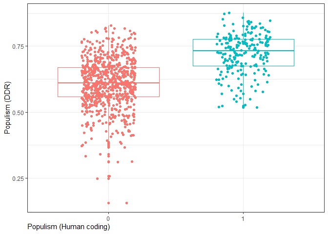

```r
tw_annot$pop %<>% factor()

ggplot(tw_annot, aes(x = pop, y = pop_ddr, color = pop)) +
  geom_boxplot()+
  geom_jitter(width = .2)+
  theme_bw()+
  labs(y = "Populism (DDR)",
       x = "Populism (Human coding)")+
  theme(axis.title.x = element_text(hjust = 0),
        legend.position="none")
```

We see that some non-populist Tweets score higher than they should, but the mean populism score for both groups is clearly different - as indicated by the boxplots.

We can also use the parallel-coded 90 Tweets to get some visual evaluation for the gradual measurement returned by the DDR method. ‘Populism’ in the annotated dataset was coded as two distinct categories, anti-elitism and people-centrism. To obtain some gradual score, we just calculate the sum of the coding of these two categories by the two coders, resulting in a score that ranges from 0 to 4. We plot it against the DDR score:

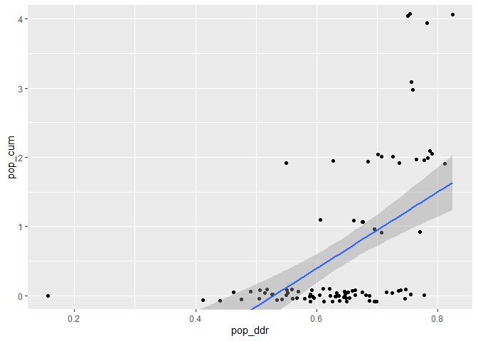

```r
parallel_df <- tw_annot %>%
  filter(rel_test == 1) %>%
  mutate(pop_cum = ppc_A + ppc_B + ane_A + ane_B)


ggplot(parallel_df, aes(x = pop_ddr, y = pop_cum))+
  geom_jitter(height = .1,
              width = 0)+
  geom_smooth(method = lm, se = T)+
  coord_cartesian(ylim = c(0,4))
```

The two (semi-)continuous scores have a Pearson’s r correlation of .53:

```r
cor(parallel_df$pop_cum, parallel_df$pop_ddr)
```

```
#> [1] 0.5324504
```

Finally, to assess external validity of our measurement, we compare it on a aggregated level to the POPPA expert rating of political parties (Meijers and Zaslove, 2020). This expert survey provides a gradual rating of populism for political parties. The score is already merged to the `tw_data`.

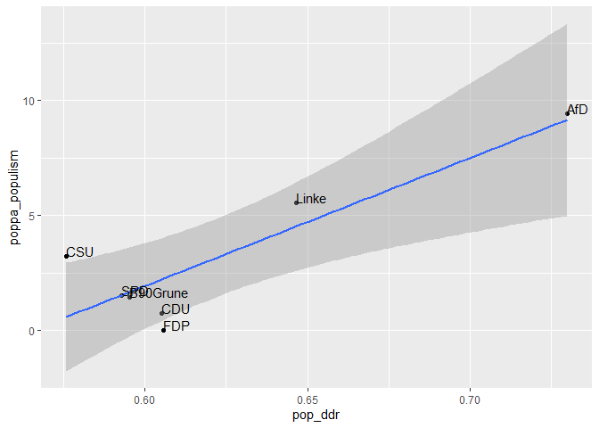

```r
# aggregate on party level
tw_party <- tw_data %>%
              group_by(party) %>%
              summarise(pop_ddr = mean(pop_ddr),
                        poppa_populism = mean(poppa_populism))


ggplot(tw_party, aes(x = pop_ddr, y = poppa_populism, label=party))+
  geom_point(na.rm = T)+
  geom_smooth(method = lm)+
  geom_text(hjust=0, vjust=0)
```

On an aggregate level, the expert ratings of populism for the political parties align very well with the DDR score for populist communication.

Indeed, both scores are strongly correlated:

```r
cor(tw_party$pop_ddr, tw_party$poppa_populism)
```

```
#> [1] 0.8763463
```

## Simple visual analysis

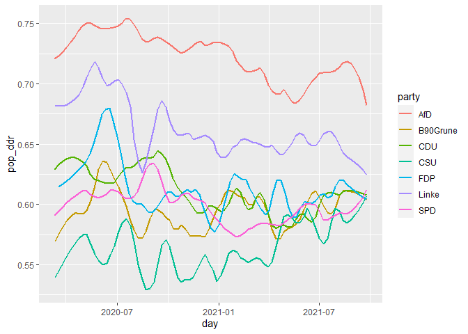

```r
tw_data %>%
    mutate(day = as.Date(created_at)) %>%
    group_by(party, day) %>%
    summarise(pop_ddr = mean(pop_ddr)) %>%
    ggplot(aes(x = day, y = pop_ddr, color = party))+
    geom_smooth(method = 'loess', span = 0.15, se = F)
```

## Conclusion

Summing up, the dictionary and measurement produced in this vignette does a good job in differentiating levels of populism in the communication of political parties, on an aggregate level. It also produces somehow plausible results when compared to the cumulative coding of the two coders. And it performs OK when compared directly to the binary hand-codings of Tweets.

However, there is much room for improvement. Here are some possible ways to improve the measurement:

- Improve the fastText model by using a much larger training dataset. Pre-trained models are trained on millions of sentences, for example. However, unlike those generic models, you may want stick with material from the specific context (here: communication of political elites).
- Improve the fastText model by parameter tuning. E.g., donsider increasing the number of dimensions (`dim`, 100-300 are popular choices), increasing the number of epochs (`epoch`), play around with different ngram lengths (`minn`, `maxn`), and play around with the window size for context (`ws`). You can use `get_nn` for face validity plausibility checks, or use a more formal test (e.g., analogy tests) to determine the quality of your fastText model.
- Use a larger annotated sample for finding good keywords and evaluating their quality. The larger this sample, the lower the risk of overfitting your short dictionary to a too specific context.
- Play around with different thresholds in `remove_similar_terms`. This function can have a quite dramatic effect of the words included or excluded.
- Think of a theory-driven, explicit coding-scheme for hand-picking words from the narrowed down subset.
- Allow for more combinations per length and dimension (`limit`) in `get_combis`.

Good luck!

## References

Bojanowski, P., Grave, E., Joulin, A., & Mikolov, T. (2017). Enriching Word Vectors with Subword Information. ArXiv:1607.04606 [Cs]. Retrieved from http://arxiv.org/abs/1607.04606

Chinchor, N. (1992). MUC-4 evaluation metrics. Proceedings of the 4th Conference on Message Understanding, 22–29. USA: Association for Computational Linguistics. https://doi.org/10.3115/1072064.1072067

Garten, J., Hoover, J., Johnson, K. M., Boghrati, R., Iskiwitch, C., & Dehghani, M. (2018). Dictionaries and distributions: Combining expert knowledge and large scale textual data content analysis. Behavior Research Methods, 50(1), 344–361. https://doi.org/10.3758/s13428-017-0875-9

Grimmer, J., & Stewart, B. M. (2013). Text as data: The promise and pitfalls of automatic content analysis methods for political texts. Political Analysis, 21(3), 267–297. https://doi.org/10.1093/pan/mps028

Meijers, M., & Zaslove, A. (2020). Populism and Political Parties Expert Survey 2018 (POPPA) (Data set). Harvard Dataverse. https://doi.org/10.7910/DVN/8NEL7B

Thiele, D. (2022, June 27). “Don’t believe the media’s pandemic propaganda!!” How Covid-19 affected populist Facebook user comments in seven European countries. Presented at the ICA Regional Conference 2022. Computational Communication Research in Central and Eastern Europe, Helsinki, Finland. Retrieved from https://ucloud.univie.ac.at/index.php/s/PzGzChXroLCXrtt